# Self-Driving Car Engineer Nanodegree

## Project: Build a Traffic Sign Recognition Classifier

In this notebook, a template is provided for you to implement your functionality in stages which is required to successfully complete this project. If additional code is required that cannot be included in the notebook, be sure that the Python code is successfully imported and included in your submission, if necessary. Sections that begin with **'Implementation'** in the header indicate where you should begin your implementation for your project. Note that some sections of implementation are optional, and will be marked with **'Optional'** in the header.

In addition to implementing code, there will be questions that you must answer which relate to the project and your implementation. Each section where you will answer a question is preceded by a **'Question'** header. Carefully read each question and provide thorough answers in the following text boxes that begin with **'Answer:'**. Your project submission will be evaluated based on your answers to each of the questions and the implementation you provide.

> **Note:** Code and Markdown cells can be executed using the **Shift + Enter** keyboard shortcut. In addition, Markdown cells can be edited by typically double-clicking the cell to enter edit mode.

## Step 0: Load The Data

```python
# Load pickled data
import pickle

# TODO: Fill this in based on where you saved the training and testing data

training_file = "traffic-signs-data/train.p"
testing_file = "traffic-signs-data/test.p"

with open(training_file, mode='rb') as f:
    train = pickle.load(f)
with open(testing_file, mode='rb') as f:
    test = pickle.load(f)

X_train, y_train = train['features'], train['labels']
X_test, y_test = test['features'], test['labels']
```

## Step 1: Dataset Summary & Exploration

The pickled data is a dictionary with 4 key/value pairs:

- `'features'` is a 4D array containing raw pixel data of the traffic sign images, (num examples, width, height, channels).
- `'labels'` is a 2D array containing the label/class id of the traffic sign. The file `signnames.csv` contains id -> name mappings for each id.
- `'sizes'` is a list containing tuples, (width, height) representing the the original width and height the image.
- `'coords'` is a list containing tuples, (x1, y1, x2, y2) representing coordinates of a bounding box around the sign in the image. **THESE COORDINATES ASSUME THE ORIGINAL IMAGE. THE PICKLED DATA CONTAINS RESIZED VERSIONS (32 by 32) OF THESE IMAGES**

Complete the basic data summary below.

```python
### Replace each question mark with the appropriate value.

# TODO: Number of training examples
n_train = X_train.shape[0]

# TODO: Number of testing examples.
n_test = X_test.shape[0]

# TODO: What's the shape of an traffic sign image?
image_shape = X_train.shape[1:]

# TODO: How many unique classes/labels there are in the dataset.
n_classes = len(set(y_train))

print("Number of training examples =", n_train)
print("Number of testing examples =", n_test)
print("Image data shape =", image_shape)
print("Number of classes =", n_classes)
```

```
Number of training examples = 39209
Number of testing examples = 12630
Image data shape = (32, 32, 3)
Number of classes = 43
```

Visualize the German Traffic Signs Dataset using the pickled file(s). This is open ended, suggestions include: plotting traffic sign images, plotting the count of each sign, etc.

The [Matplotlib](http://matplotlib.org/) [examples](http://matplotlib.org/examples/index.html) and [gallery](http://matplotlib.org/gallery.html) pages are a great resource for doing visualizations in Python.

**NOTE:** It's recommended you start with something simple first. If you wish to do more, come back to it after you've completed the rest of the sections.

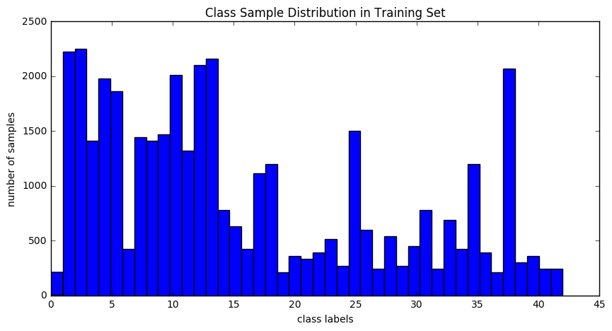

[figure not shown]

```python
### Data exploration visualization goes here.
### Feel free to use as many code cells as needed.
import matplotlib.pyplot as plt
# Visualizations will be shown in the notebook.
%matplotlib inline

# store the label, sign name, and sample image of each traffic sign
sample_data = {}

# plot the the number of samples for each traffic sign
plt.figure(figsize=(10,5))
plt.hist(y_train, bins=n_classes)
plt.xlabel('class labels')
plt.ylabel('number of samples')
plt.title('Class Sample Distribution in Training Set')
plt.show()

# get the sign names
import pandas as pd
df = pd.read_csv('signnames.csv')

# show an example of each class of traffic sign
from textwrap import wrap
from collections import Counter
label_counter = Counter(y_train)
fig = plt.figure(figsize=(10,15))
idx = 0 #image index
for label,samples in label_counter.items():
    image = X_train[idx].squeeze()
    ax = fig.add_subplot(8,8,label+1)
    ax.imshow(image)
    title = df.iloc[label,1]
    #wrap the title
    ax.set_title("\n".join(wrap(title, 12)))
    ax.set_xticks(())
    ax.set_yticks(())
    idx += samples
    sample_data[label] = (title,image)
plt.tight_layout()
```

## Step 2: Design and Test a Model Architecture

Design and implement a deep learning model that learns to recognize traffic signs. Train and test your model on the [German Traffic Sign Dataset](http://benchmark.ini.rub.de/?section=gtsrb&subsection=dataset).

There are various aspects to consider when thinking about this problem:

- Neural network architecture
- Play around preprocessing techniques (normalization, rgb to grayscale, etc)
- Number of examples per label (some have more than others).
- Generate fake data.

Here is an example of a [published baseline model on this problem](http://yann.lecun.com/exdb/publis/pdf/sermanet-ijcnn-11.pdf). It's not required to be familiar with the approach used in the paper but, it's good practice to try to read papers like these.

**NOTE:** The LeNet-5 implementation shown in the classroom at the end of the CNN lesson is a solid starting point. You'll have to change the number of classes and possibly the preprocessing, but aside from that it's plug and play!

### Implementation

Use the code cell (or multiple code cells, if necessary) to implement the first step of your project. Once you have completed your implementation and are satisfied with the results, be sure to thoroughly answer the questions that follow.

```python
### Preprocess the data here.
### Feel free to use as many code cells as needed.
```

```
process label 0 with samples 210
adding 630 samples for label 0
process label 1 with samples 2220
process label 2 with samples 2250
process label 3 with samples 1410
process label 4 with samples 1980
process label 5 with samples 1860
process label 6 with samples 420
adding 1260 samples for label 6
process label 7 with samples 1440
process label 8 with samples 1410
process label 9 with samples 1470
process label 10 with samples 2010
process label 11 with samples 1320
process label 12 with samples 2100
process label 13 with samples 2160
process label 14 with samples 780
process label 15 with samples 630
process label 16 with samples 420
adding 1260 samples for label 16
process label 17 with samples 1110
process label 18 with samples 1200
process label 19 with samples 210
adding 630 samples for label 19
process label 20 with samples 360
adding 1080 samples for label 20
process label 21 with samples 330
adding 990 samples for label 21
process label 22 with samples 390
adding 1170 samples for label 22
process label 23 with samples 510
process label 24 with samples 270
adding 810 samples for label 24
process label 25 with samples 1500
process label 26 with samples 600
process label 27 with samples 240
adding 720 samples for label 27
process label 28 with samples 540
process label 29 with samples 270
adding 810 samples for label 29
process label 30 with samples 450
adding 1350 samples for label 30
process label 31 with samples 780
process label 32 with samples 240
adding 720 samples for label 32
process label 33 with samples 689
process label 34 with samples 420
adding 1260 samples for label 34
process label 35 with samples 1200
process label 36 with samples 390
adding 1170 samples for label 36
process label 37 with samples 210
adding 630 samples for label 37
process label 38 with samples 2070
process label 39 with samples 300
adding 900 samples for label 39
process label 40 with samples 360
adding 1080 samples for label 40
process label 41 with samples 240
adding 720 samples for label 41
process label 42 with samples 240
adding 720 samples for label 42
```

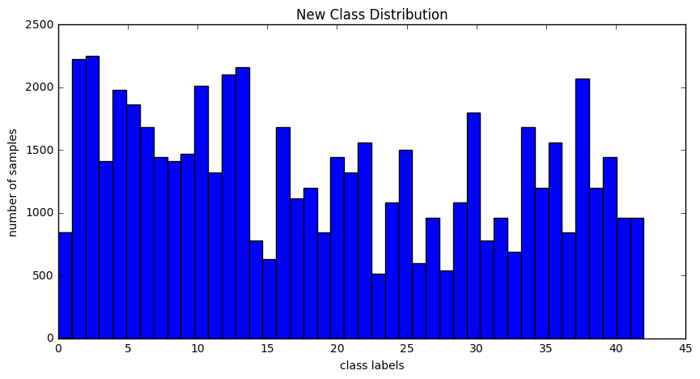

```python
import numpy as np
from scipy.ndimage.interpolation import rotate

# determine the number of samples per each class
avg_sample_count = n_train / n_classes

# create additional data for under represented classes by rotating the images
additional_samples = np.empty([0,32,32,3])
additional_labels = np.empty([0])
current = 0
for label,no_of_samples in label_counter.items():
    # if number of samples for the class is less than average / 2, create more samples by rotating images
    print("process label", label, "with samples", no_of_samples)
    if no_of_samples < avg_sample_count / 2:
        begin = current
        end = current + no_of_samples
        print("adding", 3*(end-begin), "samples", "for label", label)
        r1 = rotate(X_train[begin:end], axes=(1,2), angle=15, reshape=False)
        r2 = rotate(X_train[begin:end], axes=(1,2), angle=30, reshape=False)
        r3 = rotate(X_train[begin:end], axes=(1,2), angle=-15, reshape=False)
        additional_samples = np.concatenate([additional_samples, r1, r2, r3])
        additional_labels = np.concatenate([additional_labels, y_train[begin:end], y_train[begin:end], y_train[begin:end]])
    current = current + no_of_samples

X_train = np.concatenate([X_train, additional_samples])
y_train = np.concatenate([y_train, additional_labels])

# plot the new class distribution
plt.figure(figsize=(10,5))
plt.hist(y_train, bins=n_classes)
plt.xlabel('class labels')
plt.ylabel('number of samples')
plt.title('New Class Distribution')
plt.show()
```

```python
# zero center the data
X_train = X_train - np.mean(X_train)
X_test = X_test - np.mean(X_test)

# normalize the data
X_train = X_train / np.std(X_train)
X_test = X_test / np.std(X_test)
```

### Question 1

*Describe how you preprocessed the data. Why did you choose that technique?*

**Answer:**

We apply mean substraction by substracting the mean across every feature. We also normalize the data by dividing it by the standard deviation. This common preprocessing technique can rearrange data to have similar scale near the center.

```python
### Generate data additional data (OPTIONAL!)
### and split the data into training/validation/testing sets here.
### Feel free to use as many code cells as needed.

from sklearn.model_selection import train_test_split
X_train, X_validation, y_train, y_validation = train_test_split(X_train, y_train, test_size=0.2, random_state=42)
```

### Question 2

*Describe how you set up the training, validation and testing data for your model. **Optional**: If you generated additional data, how did you generate the data? Why did you generate the data? What are the differences in the new dataset (with generated data) from the original dataset?*

**Answer:** Use 20% of the training data for validation. Use remaining 80% of the training data for training.

For classes of traffic sign that are under represented in the training data, I created additional data by rotating the images. The additional data will result in more robust learning and protect against simliar deformations in test data.

```python
### Define your architecture here.
### Feel free to use as many code cells as needed.
from sklearn.utils import shuffle
import tensorflow as tf
EPOCHS = 100
BATCH_SIZE = 32
KEEP_PROB = 0.5

from tensorflow.contrib.layers import flatten

def LeNet(x, keep_prob):
    # Hyperparameters
    mu = 0
    sigma = 0.1

    # Layer 1: Convolutional. Input = 32x32x3. Output = 28x28x6
    w1 = tf.Variable(tf.truncated_normal(shape=(5,5,3,6), mean = mu, stddev = sigma))
    b1 = tf.Variable(tf.zeros(6))
    conv1 = tf.nn.conv2d(x, w1, strides=[1,1,1,1], padding='VALID')
    conv1 = tf.nn.bias_add(conv1, b1)
    conv1 = tf.nn.relu(conv1)
    #Pooling. Input = 28x28x6. Output = 14x14x6.
    conv1 = tf.nn.max_pool(conv1, ksize=[1,2,2,1], strides=[1,2,2,1], padding='VALID')

    # Layer 2: Convolutional. Output = 10x10x16.
    w2 = tf.Variable(tf.truncated_normal(shape=(5,5,6,16), mean = mu, stddev = sigma))
    b2 = tf.Variable(tf.zeros(16))
    conv2 = tf.nn.conv2d(conv1, w2, strides=[1,1,1,1], padding='VALID')
    conv2 = tf.nn.bias_add(conv2, b2)
    conv2 = tf.nn.relu(conv2)
    conv2 = tf.nn.max_pool(conv2, ksize=[1,2,2,1], strides=[1,2,2,1], padding='VALID')

    # Flatten. Input = 5x5x16. Output = 400.
    conv2 = flatten(conv2)

    # Layer 3: Fully Connected. Input = 400. Output = 120.
    w3 = tf.Variable(tf.truncated_normal(shape=(400,120), mean = mu, stddev = sigma))
    b3 = tf.Variable(tf.zeros(120))
    fc1 = tf.add(tf.matmul(conv2, w3), b3)
    fc1 = tf.nn.relu(fc1)

    # Dropout 1
    drop1 = tf.nn.dropout(fc1, keep_prob)

    # Layer 4: Fully Connected. Input = 120. Output = 84.
    w4 = tf.Variable(tf.truncated_normal(shape=(120,84), mean = mu, stddev = sigma))
    b4 = tf.Variable(tf.zeros(84))
    fc2 = tf.add(tf.matmul(drop1,w4), b4)
    fc2 = tf.nn.relu(fc2)

    # Dropout 2
    drop2 = tf.nn.dropout(fc2, keep_prob)

    # TODO: Layer 5: Fully Connected. Input = 84. Output = 43.
    w5 = tf.Variable(tf.truncated_normal(shape=(84,n_classes), mean = mu, stddev = sigma))
    b5 = tf.Variable(tf.zeros([n_classes]))
    logits = tf.add(tf.matmul(drop2,w5), b5)

    return logits
```

### Question 3

*What does your final architecture look like? (Type of model, layers, sizes, connectivity, etc.) For reference on how to build a deep neural network using TensorFlow, see Deep Neural Network in TensorFlow from the classroom.*

```
Training...

EPOCH 1 ... Validation Accuracy = 0.857
EPOCH 2 ... Validation Accuracy = 0.924
EPOCH 3 ... Validation Accuracy = 0.954
EPOCH 4 ... Validation Accuracy = 0.965
EPOCH 5 ... Validation Accuracy = 0.972
EPOCH 6 ... Validation Accuracy = 0.974
EPOCH 7 ... Validation Accuracy = 0.980
EPOCH 8 ... Validation Accuracy = 0.980
EPOCH 9 ... Validation Accuracy = 0.981
EPOCH 10 ... Validation Accuracy = 0.982
EPOCH 11 ... Validation Accuracy = 0.987
EPOCH 12 ... Validation Accuracy = 0.984
EPOCH 13 ... Validation Accuracy = 0.982
EPOCH 14 ... Validation Accuracy = 0.985
EPOCH 15 ... Validation Accuracy = 0.985
EPOCH 16 ... Validation Accuracy = 0.988
EPOCH 17 ... Validation Accuracy = 0.976
EPOCH 18 ... Validation Accuracy = 0.989
EPOCH 19 ... Validation Accuracy = 0.988
EPOCH 20 ... Validation Accuracy = 0.986
EPOCH 21 ... Validation Accuracy = 0.989
EPOCH 22 ... Validation Accuracy = 0.987
EPOCH 23 ... Validation Accuracy = 0.988
EPOCH 24 ... Validation Accuracy = 0.989
EPOCH 25 ... Validation Accuracy = 0.989
EPOCH 26 ... Validation Accuracy = 0.987
EPOCH 27 ... Validation Accuracy = 0.989
EPOCH 28 ... Validation Accuracy = 0.985
EPOCH 29 ... Validation Accuracy = 0.992
EPOCH 30 ... Validation Accuracy = 0.989
EPOCH 31 ... Validation Accuracy = 0.989
EPOCH 32 ... Validation Accuracy = 0.990
EPOCH 33 ... Validation Accuracy = 0.985
EPOCH 34 ... Validation Accuracy = 0.991
EPOCH 35 ... Validation Accuracy = 0.990
EPOCH 36 ... Validation Accuracy = 0.989
EPOCH 37 ... Validation Accuracy = 0.990
EPOCH 38 ... Validation Accuracy = 0.991
```

[output cut: 49 more lines]

```
EPOCH 88 ... Validation Accuracy = 0.991
EPOCH 89 ... Validation Accuracy = 0.985
EPOCH 90 ... Validation Accuracy = 0.989
EPOCH 91 ... Validation Accuracy = 0.987
EPOCH 92 ... Validation Accuracy = 0.992
EPOCH 93 ... Validation Accuracy = 0.991
EPOCH 94 ... Validation Accuracy = 0.992
EPOCH 95 ... Validation Accuracy = 0.971
EPOCH 96 ... Validation Accuracy = 0.990
EPOCH 97 ... Validation Accuracy = 0.987
EPOCH 98 ... Validation Accuracy = 0.992
EPOCH 99 ... Validation Accuracy = 0.986
EPOCH 100 ... Validation Accuracy = 0.992
Test Accuracy = 0.950
Model saved
```

```
<function matplotlib.pyplot.show>
```

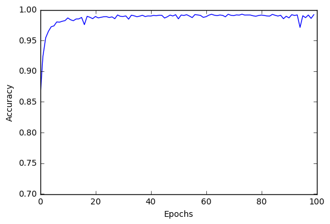

```python
### Train your model here.
### Feel free to use as many code cells as needed.
x = tf.placeholder(tf.float32, (None, 32, 32, 3))
y = tf.placeholder(tf.int32, (None))
keep_prob = tf.placeholder(tf.float32)
one_hot_y = tf.one_hot(y, n_classes)

rate = 0.001

logits = LeNet(x, keep_prob)
cross_entropy = tf.nn.softmax_cross_entropy_with_logits(logits, one_hot_y)
loss_operation = tf.reduce_mean(cross_entropy)
optimizer = tf.train.AdamOptimizer(learning_rate = rate)
training_operation = optimizer.minimize(loss_operation)


#model evaluation
correct_prediction = tf.equal(tf.argmax(logits, 1), tf.argmax(one_hot_y, 1))
accuracy_operation = tf.reduce_mean(tf.cast(correct_prediction, tf.float32))
saver = tf.train.Saver()

def evaluate(X_data, y_data):
    num_examples = len(X_data)
    total_accuracy = 0
    sess = tf.get_default_session()
    for offset in range(0, num_examples, BATCH_SIZE):
        batch_x, batch_y = X_data[offset:offset+BATCH_SIZE], y_data[offset:offset+BATCH_SIZE]
        accuracy = sess.run(accuracy_operation, feed_dict={x: batch_x, y: batch_y, keep_prob: 1.0})
        total_accuracy += (accuracy * len(batch_x))
    return total_accuracy / num_examples


#train the model
accuracy = []
with tf.Session() as sess:
    sess.run(tf.global_variables_initializer())
    num_examples = len(X_train)

    print("Training...")
    print()
    for i in range(EPOCHS):
        X_train, y_train = shuffle(X_train, y_train)
        for offset in range(0, num_examples, BATCH_SIZE):
            end = offset + BATCH_SIZE
            batch_x, batch_y = X_train[offset:end], y_train[offset:end]
            sess.run(training_operation, feed_dict={x: batch_x, y: batch_y, keep_prob: KEEP_PROB})

        validation_accuracy = evaluate(X_validation, y_validation)
        accuracy.append(validation_accuracy)
        print("EPOCH {} ...".format(i+1), "Validation Accuracy = {:.3f}".format(validation_accuracy))

    test_accuracy = evaluate(X_test, y_test)
    print("Test Accuracy = {:.3f}".format(test_accuracy))

    saver.save(sess, 'lenet')
    print("Model saved")

#plot accuracy over epochs
plt.plot(range(len(accuracy)), accuracy)
plt.ylim([0.7,1])
plt.ylabel('Accuracy')
plt.xlabel('Epochs')
plt.show
```

```python
# evaluate the model with test data
with tf.Session() as sess:
    saver.restore(sess, tf.train.latest_checkpoint('.'))

    test_accuracy = evaluate(X_test, y_test)
    print("Test Accuracy = {:.3f}".format(test_accuracy))
```

```
Test Accuracy = 0.950
```

### Question 4

*How did you train your model? (Type of optimizer, batch size, epochs, hyperparameters, etc.)*

**Answer:**

I used AdamOptimizer with a learning rate of 0.001. I had experimented with lowering learning rate, it requires a much larger epochs and as a result, much longer training time with only marginal improvement.

I used 100 epochs. I had experiemented with much larger epochs (>1000) combined with lower learning rate, it resulted with some marginal validation accuracy, but much longer training time.

I used two drop out layers with 0.5 keep probability, one after each fully connected layer. The dropout layers are added to prevent overfitting.

I used a batch size of 32. I picked 32 mainly due to the limitation of my machine I used to train which had a 1GB of GPU memory. However, I did experiment with much larger batch size (up to 4096) when I used Amazon EC2 instance. I found that it improved the training time greatly, but didn't improve validation accuracy.

### Question 5

*What approach did you take in coming up with a solution to this problem? It may have been a process of trial and error, in which case, outline the steps you took to get to the final solution and why you chose those steps. Perhaps your solution involved an already well known implementation or architecture. In this case, discuss why you think this is suitable for the current problem.*

**Answer:** The entire solution is the result of many trial and errors.

For my first attempt, I simply adapted the LeNet Lab to this problem. I had to adjust the input from depth of 1 (grayscale in MINIST) to depth of 3 (color in traffic signs). I also had to adjust the final layer to n_classes (43) from 10. This alone got the validation accuracy to 96%.

Next, I did many experiements by adjusting various hyper parameters on the existing model. When I used 500 epochs and I noticed the validation accuracy started to go down after 200 epochs. I suspected the model overshot optimum. I adjusted the learning rate from 0.001 to 0.0001. After this adjustment, with 0.0001 learning rate and 500 epochs, the validation accuracy increased to 99%.

[figure not shown]

Next I experiemented changing the architecture. The first idea I had was related to the padding. The first conv layer from LeNet lab was cutting off the edges. The first layer with input of 32x32 with out 28x28. This cutoff was fine for MINIST in the LeNet lab was the original input was smaller and had zero padded around the edges. I thought if there are useful features in the traffic sign images, they could get cut off. Based on that idea, I updated the first conv layer to use 'SAME' instead of 'VALID'. This will give an output of 32x32 after the first conv layer. However, that didn't produce any noticeable improvement. I also experimented with different depths in the conv layers without noticeable improvement.

Next, I experiemented with the batch size. On my local machine, my GPU only has 1GB memory, and I couldn't use anything bigger than a batch size of 32. To get around that limiation, I started using an Amazon EC2 gp2 instance. ON the Amazon instance, I could use batch size of 4096. The training time was a lot faster, but the accuracy wasn't improving.

Next, reasonably satifitied with the 99% valiation accuracy, I gave the test data a shot. The test accuracy is ~92%, quite a big gap from the validation accuracy. This clearly indicated the model is overfitting. Also, this could also be a result of deformed images in the test set that the trained model couldn't predict.

Equipped with what I learnt from the last experiment. Next, I added preprocessing. I normalized the data. I also generated additional training data. I also noticed there are many classes that are very under represented in the training data. I generated the additional data for those classes by rotating the images. I also added two dropout layers, one after each fully connected layer to combat overfitting. With the new pipeline, I could increase the learning rate, decrease the epochs and speed up the training, and achieved a 99.2% validation accuracy and 95% test accuracy.

## Step 3: Test a Model on New Images

Take several pictures of traffic signs that you find on the web or around you (at least five), and run them through your classifier on your computer to produce example results. The classifier might not recognize some local signs but it could prove interesting nonetheless.

You may find `signnames.csv` useful as it contains mappings from the class id (integer) to the actual sign name.

### Implementation

Use the code cell (or multiple code cells, if necessary) to implement the first step of your project. Once you have completed your implementation and are satisfied with the results, be sure to thoroughly answer the questions that follow.

```python
### Load the images and plot them here.
### Feel free to use as many code cells as needed.
import matplotlib.image as mpimg
import numpy as np
import os
import cv2

extras = [
    { "file": "img1.png", "image": None, "pred_label": None, "label": 13, "sign": "Yield" },
    { "file": "img2.png", "image": None, "pred_label": None, "label": 14, "sign": "Stop" },
    { "file": "img3.png", "image": None, "pred_label": None, "label": 17, "sign": "No Entry" },
    { "file": "img4.png", "image": None, "pred_label": None, "label": 18, "sign": "General Caution" },
    { "file": "img5.png", "image": None, "pred_label": None, "label": 28, "sign": "Children Crossing" },
    { "file": "img6.png", "image": None, "pred_label": None, "label": -1, "sign": "Railroad Crossing" },
];

for extra in extras:
    image = mpimg.imread("extra/" + extra["file"])
    image = image[:,:,:3]
    extra["image"] = cv2.resize(image, (32,32))
```

### Question 6

*Choose five candidate images of traffic signs and provide them in the report. Are there any particular qualities of the image(s) that might make classification difficult? It could be helpful to plot the images in the notebook.*

**Answer:**

[figure not shown]

```python
### Run the predictions here.
### Feel free to use as many code cells as needed.
import tensorflow as tf

# run predictions
with tf.Session() as sess:
    saver.restore(sess, tf.train.latest_checkpoint('.'))
    pred = sess.run(tf.argmax(logits, 1), feed_dict = { x: [e["image"] for e in extras], keep_prob: 1.0})

# store predictions in extras
for i in range(len(pred)):
    extras[i]["pred_label"] = pred[i]

# plot result
fig = plt.figure(figsize = (10,6))
for idx, extra in enumerate(extras):
    ax = fig.add_subplot(len(extras), 3, idx * 3 + 1)
    ax.imshow(extra["image"])
    ax.set_xticks(())
    ax.set_yticks(())
    correctness = "CORRECT" if extra["label"] == extra["pred_label"] else "WRONG"
    ax.text(40,20,"Prediction: {0}\nPredicted Label: {1}\nCorrect Label: {2}".format(correctness, extra["pred_label"], extra["label"]))

    ax = fig.add_subplot(len(extras), 3, idx * 3 + 2)
    ax.imshow(sample_data[extra["pred_label"]][1])
    ax.set_xticks(())
    ax.set_yticks(())
    ax.text(40,20,"Predicted\n{0}".format(sample_data[extra["pred_label"]][0]))

    ax = fig.add_subplot(len(extras), 3, idx * 3 + 3)
    ax.set_xticks(())
    ax.set_yticks(())
    correct_label = extra["label"]
    if correct_label == -1:
        ax.imshow(np.zeros((32,32,3)))
        ax.text(40,20,"Actual\n{0}\n(Not in set)".format(extra["sign"]))
    else:
        ax.imshow(sample_data[extra["label"]][1])
        ax.text(40,20,"Actual\n{0}".format(sample_data[extra["label"]][0]))
plt.tight_layout()
```

The are two images that model did not predict correctly.

Children crossing. This sign is in the training set, but there are quite a few differences with the extra image that could throw off the model. First, The shape of the sign in the training set is triangle, with thick red border. The shape of the sign in the extra image is pentagon, and it's entirely yellow with much thinner border. Also, the shape of the two people in the signs are different. Moreover, the extra image has a line of words at the bottom of the sign that's missing in the training set.

Railroad crossing. This image is not in the training set, so the model could never have predicted correctly.

### Question 7

*Is your model able to perform equally well on captured pictures when compared to testing on the dataset? The simplest way to do this check the accuracy of the predictions. For example, if the model predicted 1 out of 5 signs correctly, it's 20% accurate.*

**NOTE:** You could check the accuracy manually by using `signnames.csv` (same directory). This file has a mapping from the class id (0-42) to the corresponding sign name. So, you could take the class id the model outputs, lookup the name in `signnames.csv` and see if it matches the sign from the image.

**Answer:**

On the new images, the accuracy is 66.7%. This is not nearly as good as the 95% test accuracy. This is partially due to the railroad crossing image that's not in the training set, and the differences the children crossing image.

[figure not shown]

```python
### Visualize the softmax probabilities here.
### Feel free to use as many code cells as needed.
import tensorflow as tf

# run top_k on softmax
with tf.Session() as sess:
    saver.restore(sess, tf.train.latest_checkpoint('.'))
    topk = sess.run(tf.nn.top_k(tf.nn.softmax(logits), k=5), feed_dict = { x: [e["image"] for e in extras], keep_prob: 1.0})
# print(topk)

# store predictions to plot later
for i in range(len(extras)):
    extras[i]["top1img"] = sample_data[topk[1][i][0]][1]
    extras[i]["top1pct"] = round(topk[0][i][0] * 100, 2)
    extras[i]["top2img"] = sample_data[topk[1][i][1]][1]
    extras[i]["top2pct"] = round(topk[0][i][1] * 100, 2)
    extras[i]["top3img"] = sample_data[topk[1][i][2]][1]
    extras[i]["top3pct"] = round(topk[0][i][2] * 100, 2)

#for e in extras:
#    print(e["topk"], e["topkpct"])

# plot result
fig = plt.figure(figsize = (10,6))
for idx, extra in enumerate(extras):
    ax = fig.add_subplot(len(extras), 4, idx * 4 + 1)
    ax.imshow(extra["image"])
    ax.set_xticks(())
    ax.set_yticks(())
    correctness = "CORRECT" if extra["label"] == extra["pred_label"] else "WRONG"
    ax.text(40,20,"{0}\nPredicted : {1}\nCorrect : {2}".format(correctness, extra["pred_label"], extra["label"]))

    ax = fig.add_subplot(len(extras), 4, idx * 4 + 2)
    ax.imshow(extra["top1img"])
    ax.set_xticks(())
    ax.set_yticks(())
    ax.text(40,20,"Percentage\n{0}".format(extra["top1pct"]))

    ax = fig.add_subplot(len(extras), 4, idx * 4 + 3)
    ax.imshow(extra["top2img"])
    ax.set_xticks(())
    ax.set_yticks(())
    ax.text(40,20,"Percentage\n{0}".format(extra["top2pct"]))

    ax = fig.add_subplot(len(extras), 4, idx * 4 + 4)
    ax.imshow(extra["top3img"])
    ax.set_xticks(())
    ax.set_yticks(())
    ax.text(40,20,"Percentage\n{0}".format(extra["top3pct"]))
plt.tight_layout()
```

### Question 8

*Use the model's softmax probabilities to visualize the **certainty** of its predictions, [`tf.nn.top_k`](https://www.tensorflow.org/versions/r0.12/api_docs/python/nn.html#top_k) could prove helpful here. Which predictions is the model certain of? Uncertain? If the model was incorrect in its initial prediction, does the correct prediction appear in the top k? (k should be 5 at most)*

`tf.nn.top_k` will return the values and indices (class ids) of the top k predictions. So if k=3, for each sign, it'll return the 3 largest probabilities (out of a possible 43) and the correspoding class ids.

Take this numpy array as an example:

```
# (5, 6) array
a = np.array([[ 0.24879643,  0.07032244,  0.12641572,  0.34763842,  0.07893497,
         0.12789202],
       [ 0.28086119,  0.27569815,  0.08594638,  0.0178669 ,  0.18063401,
         0.15899337],
       [ 0.26076848,  0.23664738,  0.08020603,  0.07001922,  0.1134371 ,
         0.23892179],
       [ 0.11943333,  0.29198961,  0.02605103,  0.26234032,  0.1351348 ,
         0.16505091],
       [ 0.09561176,  0.34396535,  0.0643941 ,  0.16240774,  0.24206137,
         0.09155967]])
```

Running it through `sess.run(tf.nn.top_k(tf.constant(a), k=3))` produces:

```
TopKV2(values=array([[ 0.34763842,  0.24879643,  0.12789202],
       [ 0.28086119,  0.27569815,  0.18063401],
       [ 0.26076848,  0.23892179,  0.23664738],
       [ 0.29198961,  0.26234032,  0.16505091],
       [ 0.34396535,  0.24206137,  0.16240774]]), indices=array([[3, 0, 5],
       [0, 1, 4],
       [0, 5, 1],
       [1, 3, 5],
       [1, 4, 3]], dtype=int32))
```

Looking just at the first row we get `[ 0.34763842, 0.24879643, 0.12789202]`, you can confirm these are the 3 largest probabilities in `a`. You'll also notice `[3, 0, 5]` are the corresponding indices.

**Answer:**

The model predicted correctly with 100% certainty on 3 images!

The model predicted the stop sign correctly at 99.32%. This is a bit less cerain than the other 3 correctly predicted image. This is possibly due to the background in the stop sign in the extra image. It has a much busier background compared to other images.

The model predicated the childred crossing sign incorrectly with a low certainty at 50.23%. This is a local sign that has many differences with the sign in the training set, so the low certainty makes sense. Interestingly, the next two highest probable prediction didn't include the correct sign. I ran top_k to include all predictions, the correct result came in at number 12 with 0.7% certainty.

The model predicated the railroad crossing sign incorrectly with a high certainly at 94.77%. This image is not in the training data so the model could never have predicatd it correctly. The model predicated it as the 30 km/h speed limit sign. There are some similarities between both signs. They both have have circular border. They both have two characters in the middle. However, they look quite different visually. I am surprised the model predicated with such high certainty.